# Serco Maintenance Event Modelling - Standard Linear Modelling

## Summary

This uses the full dataset.

We’re doing regression because we want to predict a number. (the predicted number of maintenance incidents for the proerty in the month).

*Import Libraries*

```r
library("tidyverse")
library("dplyr")
library("plyr")
library(lubridate)
library(stringr)
library(caret, quietly = TRUE)
library(hydroGOF)
library(gbm)
library(xgboost)
library(glmnet)
library("FactoMineR")
library("factoextra")
library(corrplot)
library(caret)
library(corrplot)
library(xgboost)
library(stats)
library(knitr)
library(ggplot2)
library(Matrix)
library(plotly)
library(htmlwidgets)
library(readr)
library(randomForest)
library(data.table)
library(h2o)
library(dplyr)
library(tidyr)
library(Hmisc)
library(psych)
```

Load maintenance events which includes data on the nature of the fault, the fix information and the costs.

```r
#load the fault fix data
rawMaintenanceEvents <- read.csv("csv/Fault Fixed - Costings - Modified.csv", skip=0, stringsAsFactors = FALSE)
nrow(rawMaintenanceEvents)
```

```
[1] 105230
```

```r
#rename 'Address', 'Accommodation.Type' and 'Housing.Officer' fields because they are common to both datasets we will join
names(rawMaintenanceEvents)[names(rawMaintenanceEvents)=="Address"] <- "Event.Address"
names(rawMaintenanceEvents)[names(rawMaintenanceEvents)=="Accommodation.Type"] <- "Event.Accommodation.Type"
names(rawMaintenanceEvents)[names(rawMaintenanceEvents)=="Housing.Officer"] <- "Event.Housing.Officer"
#convert 'Identified.date' date strings to actual dates - We use the lubridate package to parse the datetimes and we use the very useful parse_date_time method because it allow us to specify different format patterns.  This is needed because some of the values in the 'identified date' column have seconds and some dont.  The first format is used for the parsing and if that fails, the second format is used.  Beware that if we just used the second format on a datetime with no seconds it wouldn't error but it would produce the wrong result (the year would be 2020.. which is totally wrong).
#See (https://skgrange.github.io/date_handling.html) for more information.
rawMaintenanceEvents <- mutate(rawMaintenanceEvents, Identified.date= parse_date_time(Identified.date, orders = c("dmy_HM", "dmy_HMS"), tz = "UTC"))
nrow(rawMaintenanceEvents)
```

```
[1] 105230
```

```r
#filter to only keep events identified in 2017
#we exclude 2422 rows that have a blank Identified Date or an Identified date that is in 2016
filteredMaintenanceEvents <- filter(rawMaintenanceEvents, Identified.date >= dmy_hms("01-01-2017 00:00:00"))
nrow(filteredMaintenanceEvents)
```

```
[1] 102808
```

```r
#127 rows have invalid ASYS value,including blanks -29 without blanks with values of (DON'T USE, DUPLICATE, DUPLICATE ARCHIVED, TBC)
invalidAsysRows <- subset(filteredMaintenanceEvents, is.na(as.numeric(as.character(filteredMaintenanceEvents$ASYS))),)
invalidAsysRows
```

| Fault.Reference | Property.Status.at.Capture | ASYS | Event.Address | No.of.Occupants | Fault.Identified.By | Identified.date | Registered.Date | Registered.By | Date.last.amended | Amended.By | Event.Housing.Officer | Classification | Type | Other.details | Location | Item.Category | Room.Number | Item | Defect | Issue | Fault.Information | Assigned.to | Contractor | Maintenance.Supervisor | Maintenance.Officer | Fault.End.Date | Contract.End.Date | Date.Fault.Fixed | Fixed.By | … |
| --- | --- | --- | --- | --- | --- | --- | --- | --- | --- | --- | --- | --- | --- | --- | --- | --- | --- | --- | --- | --- | --- | --- | --- | --- | --- | --- | --- | --- | --- | --- |

```r
nrow(invalidAsysRows)
```

[output not shown]

```r
#Do the conversion of ASYS numbers to actual numbers - anything that doesn't convert changes to NA.
convertedMaintenanceEvents <- mutate(filteredMaintenanceEvents, ASYS= as.numeric(as.character(filteredMaintenanceEvents$ASYS)))
nrow(convertedMaintenanceEvents)
```

[output not shown]

```r
#filter out 127 rows with NA ASYS number
validAsysMaintenanceEvents <- subset(convertedMaintenanceEvents, !is.na(convertedMaintenanceEvents$ASYS),)
nrow(validAsysMaintenanceEvents)
```

```
[1] 102681
```

```r
#There is no property data for January so we'll won't use it
#validAsysMaintenanceEventsJan <- validAsysMaintenanceEvents[validAsysMaintenanceEvents$Fault.Identified.Month.Number == 1,]
```

```r
validAsysMaintenanceEventsFeb <- validAsysMaintenanceEvents[validAsysMaintenanceEvents$Fault.Identified.Month.Number == 2,]
validAsysMaintenanceEventsMar <- validAsysMaintenanceEvents[validAsysMaintenanceEvents$Fault.Identified.Month.Number == 3,]
validAsysMaintenanceEventsApr <- validAsysMaintenanceEvents[validAsysMaintenanceEvents$Fault.Identified.Month.Number == 4,]
validAsysMaintenanceEventsMay <- validAsysMaintenanceEvents[validAsysMaintenanceEvents$Fault.Identified.Month.Number == 5,]
validAsysMaintenanceEventsJun <- validAsysMaintenanceEvents[validAsysMaintenanceEvents$Fault.Identified.Month.Number == 6,]
validAsysMaintenanceEventsJul <- validAsysMaintenanceEvents[validAsysMaintenanceEvents$Fault.Identified.Month.Number == 7,]
validAsysMaintenanceEventsAug <- validAsysMaintenanceEvents[validAsysMaintenanceEvents$Fault.Identified.Month.Number == 8,]
validAsysMaintenanceEventsSep <- validAsysMaintenanceEvents[validAsysMaintenanceEvents$Fault.Identified.Month.Number == 9,]
```

```r
#No maintenance events in October - we will not use
validAsysMaintenanceEventsOct <- validAsysMaintenanceEvents[validAsysMaintenanceEvents$Fault.Identified.Month.Number == 10,]
```

```r
#FEBRUARY
#load the property data - 2917 rows  (should be 2915)  (the import pulls in two totally blank rows at the end which are filtered out by the ASYS check routine).
rawPropertyDataFeb <- read.csv("csv/Available_Bedrooms_And_Bedspaces_NW_2017-02-01.csv", skip=3, stringsAsFactors = FALSE)

#filter out rows that do not have a valid ASYS value - 5 rows (3 genuine and 2 blanks from import)
validAsysPropertyDataFeb <- filter(rawPropertyDataFeb, !is.na(as.numeric(as.character(rawPropertyDataFeb$ASYS))),)
nrow(validAsysPropertyDataFeb)
#valid row count is correct at 2912 - 5 rows excluded (3 genuine and 2 blanks from import)

#MARCH
#load the property data
rawPropertyDataMar <- read.csv("csv/Available_Bedrooms_And_Bedspaces_NW_2017-03-01.csv", skip=3, stringsAsFactors = FALSE)

#filter out rows that do not have a valid ASYS value
validAsysPropertyDataMar <- filter(rawPropertyDataMar, !is.na(as.numeric(as.character(rawPropertyDataMar$ASYS))),)
nrow(validAsysPropertyDataMar)
#Row count correct at 2931 - 7 blank asys

#APRIL
#load the property data
rawPropertyDataApr <- read.csv("csv/Available_Bedrooms_And_Bedspaces_NW_2017-04-01.csv", skip=3, stringsAsFactors = FALSE)

#filter out rows that do not have a valid ASYS value
validAsysPropertyDataApr <- filter(rawPropertyDataApr, !is.na(as.numeric(as.character(rawPropertyDataApr$ASYS))),)
nrow(validAsysPropertyDataApr)
#Row count correct at 2931 - 3 blank asys

#MAY
#load the property data
rawPropertyDataMay <- read.csv("csv/Available_Bedrooms_And_Bedspaces_NW_2017-05-01.csv", skip=3, stringsAsFactors = FALSE)

#filter out rows that do not have a valid ASYS value
validAsysPropertyDataMay <- filter(rawPropertyDataMay, !is.na(as.numeric(as.character(rawPropertyDataMay$ASYS))),)
nrow(validAsysPropertyDataMay)
#Row count correct at 2933 - 2 blank asys

#JUNE
#load the property data
rawPropertyDataJun <- read.csv("csv/Available_Bedrooms_And_Bedspaces_NW_2017-06-01.csv", skip=3, stringsAsFactors = FALSE)

#filter out rows that do not have a valid ASYS value
validAsysPropertyDataJun <- filter(rawPropertyDataJun, !is.na(as.numeric(as.character(rawPropertyDataJun$ASYS))),)
nrow(validAsysPropertyDataJun)
#Row count correct at 2933 - 9 blank asys

#JUL
#load the property data
rawPropertyDataJul <- read.csv("csv/Available_Bedrooms_And_Bedspaces_NW_2017-07-01.csv", skip=3, stringsAsFactors = FALSE)

#filter out rows that do not have a valid ASYS value
validAsysPropertyDataJul <- filter(rawPropertyDataJul, !is.na(as.numeric(as.character(rawPropertyDataJul$ASYS))),)
nrow(validAsysPropertyDataJul)
#Row count correct at 2934 - 18 blank asys

#AUG
#load the property data
rawPropertyDataAug <- read.csv("csv/Available_Bedrooms_And_Bedspaces_NW_2017-08-01.csv", skip=3, stringsAsFactors = FALSE)

#filter out rows that do not have a valid ASYS value
validAsysPropertyDataAug <- filter(rawPropertyDataAug, !is.na(as.numeric(as.character(rawPropertyDataAug$ASYS))),)
nrow(validAsysPropertyDataAug)
#Row count correct at 2942 - 8 blank asys and 1 marked 'DUPLICATE'

#SEP
#load the property data
rawPropertyDataSep <- read.csv("csv/Available_Bedrooms_And_Bedspaces_NW_2017-09-01.csv", skip=3, stringsAsFactors = FALSE)

#filter out rows that do not have a valid ASYS value
validAsysPropertyDataSep <- filter(rawPropertyDataSep, !is.na(as.numeric(as.character(rawPropertyDataSep$ASYS))),)
nrow(validAsysPropertyDataSep)
#Row count correct at 2935 - 18 blank asys

#OCT
#load the property data
rawPropertyDataOct <- read.csv("csv/Available_Bedrooms_And_Bedspaces_NW_2017-10-01.csv", skip=3, stringsAsFactors = FALSE)

#filter out rows that do not have a valid ASYS value
validAsysPropertyDataOct <- filter(rawPropertyDataOct, !is.na(as.numeric(as.character(rawPropertyDataOct$ASYS))),)
nrow(validAsysPropertyDataOct)
#Row count correct at 2953 - 5 blank asys
```

```r
#remove negative bedspaces
validAsysPropertyDataFeb$Negative.Bedspaces <- ifelse(validAsysPropertyDataFeb$Available.Bedspaces < 0, abs(validAsysPropertyDataFeb$Available.Bedspaces), 0)
validAsysPropertyDataFeb$Available.Bedspaces <- ifelse(validAsysPropertyDataFeb$Available.Bedspaces < 0, 0, validAsysPropertyDataFeb$Available.Bedspaces)

#remove negative bedrooms
validAsysPropertyDataFeb$Negative.Bedrooms <- ifelse(validAsysPropertyDataFeb$Available.Bedrooms < 0, abs(validAsysPropertyDataFeb$Available.Bedrooms), 0)
validAsysPropertyDataFeb$Available.Bedrooms <- ifelse(validAsysPropertyDataFeb$Available.Bedrooms < 0, 0, validAsysPropertyDataFeb$Available.Bedrooms)



#remove negative bedspaces
validAsysPropertyDataMar$Negative.Bedspaces <- ifelse(validAsysPropertyDataMar$Available.Bedspaces < 0, abs(validAsysPropertyDataMar$Available.Bedspaces), 0)
validAsysPropertyDataMar$Available.Bedspaces <- ifelse(validAsysPropertyDataMar$Available.Bedspaces < 0, 0, validAsysPropertyDataMar$Available.Bedspaces)

#remove negative bedrooms
validAsysPropertyDataMar$Negative.Bedrooms <- ifelse(validAsysPropertyDataMar$Available.Bedrooms < 0, abs(validAsysPropertyDataMar$Available.Bedrooms), 0)
validAsysPropertyDataMar$Available.Bedrooms <- ifelse(validAsysPropertyDataMar$Available.Bedrooms < 0, 0, validAsysPropertyDataMar$Available.Bedrooms)


#remove negative bedspaces
validAsysPropertyDataApr$Negative.Bedspaces <- ifelse(validAsysPropertyDataApr$Available.Bedspaces < 0, abs(validAsysPropertyDataApr$Available.Bedspaces), 0)
validAsysPropertyDataApr$Available.Bedspaces <- ifelse(validAsysPropertyDataApr$Available.Bedspaces < 0, 0, validAsysPropertyDataApr$Available.Bedspaces)

#remove negative bedrooms
validAsysPropertyDataApr$Negative.Bedrooms <- ifelse(validAsysPropertyDataApr$Available.Bedrooms < 0, abs(validAsysPropertyDataApr$Available.Bedrooms), 0)
validAsysPropertyDataApr$Available.Bedrooms <- ifelse(validAsysPropertyDataApr$Available.Bedrooms < 0, 0, validAsysPropertyDataApr$Available.Bedrooms)

#remove negative bedspaces
validAsysPropertyDataMay$Negative.Bedspaces <- ifelse(validAsysPropertyDataMay$Available.Bedspaces < 0, abs(validAsysPropertyDataMay$Available.Bedspaces), 0)
validAsysPropertyDataMay$Available.Bedspaces <- ifelse(validAsysPropertyDataMay$Available.Bedspaces < 0, 0, validAsysPropertyDataMay$Available.Bedspaces)

#remove negative bedrooms
validAsysPropertyDataMay$Negative.Bedrooms <- ifelse(validAsysPropertyDataMay$Available.Bedrooms < 0, abs(validAsysPropertyDataMay$Available.Bedrooms), 0)
validAsysPropertyDataMay$Available.Bedrooms <- ifelse(validAsysPropertyDataMay$Available.Bedrooms < 0, 0, validAsysPropertyDataMay$Available.Bedrooms)


#remove negative bedspaces
validAsysPropertyDataJun$Negative.Bedspaces <- ifelse(validAsysPropertyDataJun$Available.Bedspaces < 0, abs(validAsysPropertyDataJun$Available.Bedspaces), 0)
validAsysPropertyDataJun$Available.Bedspaces <- ifelse(validAsysPropertyDataJun$Available.Bedspaces < 0, 0, validAsysPropertyDataJun$Available.Bedspaces)

#remove negative bedrooms
validAsysPropertyDataJun$Negative.Bedrooms <- ifelse(validAsysPropertyDataJun$Available.Bedrooms < 0, abs(validAsysPropertyDataJun$Available.Bedrooms), 0)
validAsysPropertyDataJun$Available.Bedrooms <- ifelse(validAsysPropertyDataJun$Available.Bedrooms < 0, 0, validAsysPropertyDataJun$Available.Bedrooms)


#remove negative bedspaces
validAsysPropertyDataJul$Negative.Bedspaces <- ifelse(validAsysPropertyDataJul$Available.Bedspaces < 0, abs(validAsysPropertyDataJul$Available.Bedspaces), 0)
validAsysPropertyDataJul$Available.Bedspaces <- ifelse(validAsysPropertyDataJul$Available.Bedspaces < 0, 0, validAsysPropertyDataJul$Available.Bedspaces)

#remove negative bedrooms
validAsysPropertyDataJul$Negative.Bedrooms <- ifelse(validAsysPropertyDataJul$Available.Bedrooms < 0, abs(validAsysPropertyDataJul$Available.Bedrooms), 0)
validAsysPropertyDataJul$Available.Bedrooms <- ifelse(validAsysPropertyDataJul$Available.Bedrooms < 0, 0, validAsysPropertyDataJul$Available.Bedrooms)


#remove negative bedspaces
validAsysPropertyDataAug$Negative.Bedspaces <- ifelse(validAsysPropertyDataAug$Available.Bedspaces < 0, abs(validAsysPropertyDataAug$Available.Bedspaces), 0)
validAsysPropertyDataAug$Available.Bedspaces <- ifelse(validAsysPropertyDataAug$Available.Bedspaces < 0, 0, validAsysPropertyDataAug$Available.Bedspaces)

#remove negative bedrooms
validAsysPropertyDataAug$Negative.Bedrooms <- ifelse(validAsysPropertyDataAug$Available.Bedrooms < 0, abs(validAsysPropertyDataAug$Available.Bedrooms), 0)
validAsysPropertyDataAug$Available.Bedrooms <- ifelse(validAsysPropertyDataAug$Available.Bedrooms < 0, 0, validAsysPropertyDataAug$Available.Bedrooms)


#remove negative bedspaces
validAsysPropertyDataSep$Negative.Bedspaces <- ifelse(validAsysPropertyDataSep$Available.Bedspaces < 0, abs(validAsysPropertyDataSep$Available.Bedspaces), 0)
validAsysPropertyDataSep$Available.Bedspaces <- ifelse(validAsysPropertyDataSep$Available.Bedspaces < 0, 0, validAsysPropertyDataSep$Available.Bedspaces)

#remove negative bedrooms
validAsysPropertyDataSep$Negative.Bedrooms <- ifelse(validAsysPropertyDataSep$Available.Bedrooms < 0, abs(validAsysPropertyDataSep$Available.Bedrooms), 0)
validAsysPropertyDataSep$Available.Bedrooms <- ifelse(validAsysPropertyDataSep$Available.Bedrooms < 0, 0, validAsysPropertyDataSep$Available.Bedrooms)


#remove negative bedspaces
validAsysPropertyDataOct$Negative.Bedspaces <- ifelse(validAsysPropertyDataOct$Available.Bedspaces < 0, abs(validAsysPropertyDataOct$Available.Bedspaces), 0)
validAsysPropertyDataOct$Available.Bedspaces <- ifelse(validAsysPropertyDataOct$Available.Bedspaces < 0, 0, validAsysPropertyDataOct$Available.Bedspaces)

#remove negative bedrooms
validAsysPropertyDataOct$Negative.Bedrooms <- ifelse(validAsysPropertyDataOct$Available.Bedrooms < 0, abs(validAsysPropertyDataOct$Available.Bedrooms), 0)
validAsysPropertyDataOct$Available.Bedrooms <- ifelse(validAsysPropertyDataOct$Available.Bedrooms < 0, 0, validAsysPropertyDataOct$Available.Bedrooms)
```

*Pair faults with property data*

```r
#property 2912 rows
#events Feb 11304
propertyEventsFeb <- join(x = validAsysPropertyDataFeb, y = validAsysMaintenanceEventsFeb, by = c("ASYS"), type = "left", match = "all")
#assign a month number to properties that have no fault so that they are month aligned
propertyEventsFeb$Fault.Identified.Month.Number[is.na(propertyEventsFeb$Fault.Identified.Month.Number)] <- 2
#This tells us how many unique properties there are in the dataset - should be the same as the number of properties in the
#monthly property data.  Rows with NA in the fault reference are properties that have no faults
tmpFeb <- plyr::count(propertyEventsFeb, "ASYS")
#11304 rows with a fault reference - rest should be NA
```

```r
propertyEventsMar <- join(x = validAsysPropertyDataMar, y = validAsysMaintenanceEventsMar, by = c("ASYS"), type = "left", match = "all")
#assign a month number to properties that have no fault so that they are month aligned
propertyEventsMar$Fault.Identified.Month.Number[is.na(propertyEventsMar$Fault.Identified.Month.Number)] <- 3
#This tells us how many unique properties there are in the dataset - should be the same as the number of properties in the
#monthly property data.  Rows with NA in the fault reference are properties that have no faults
tmpMar <- plyr::count(propertyEventsMar, "ASYS")
propertyEventsApr <- join(x = validAsysPropertyDataApr, y = validAsysMaintenanceEventsApr, by = c("ASYS"), type = "left", match = "all")
#assign a month number to properties that have no fault so that they are month aligned
propertyEventsApr$Fault.Identified.Month.Number[is.na(propertyEventsApr$Fault.Identified.Month.Number)] <- 4
#This tells us how many unique properties there are in the dataset - should be the same as the number of properties in the
#monthly property data.  Rows with NA in the fault reference are properties that have no faults
tmpApr <- plyr::count(propertyEventsApr, "ASYS")
propertyEventsMay <- join(x = validAsysPropertyDataMay, y = validAsysMaintenanceEventsMay, by = c("ASYS"), type = "left", match = "all")
#assign a month number to properties that have no fault so that they are month aligned
propertyEventsMay$Fault.Identified.Month.Number[is.na(propertyEventsMay$Fault.Identified.Month.Number)] <- 5
#This tells us how many unique properties there are in the dataset - should be the same as the number of properties in the
#monthly property data.  Rows with NA in the fault reference are properties that have no faults
tmpMay <- plyr::count(propertyEventsMay, "ASYS")
propertyEventsJun <- join(x = validAsysPropertyDataJun, y = validAsysMaintenanceEventsJun, by = c("ASYS"), type = "left", match = "all")
#assign a month number to properties that have no fault so that they are month aligned
propertyEventsJun$Fault.Identified.Month.Number[is.na(propertyEventsJun$Fault.Identified.Month.Number)] <- 6
#This tells us how many unique properties there are in the dataset - should be the same as the number of properties in the
#monthly property data.  Rows with NA in the fault reference are properties that have no faults
tmpJun <- plyr::count(propertyEventsJun, "ASYS")
propertyEventsJul <- join(x = validAsysPropertyDataJul, y = validAsysMaintenanceEventsJul, by = c("ASYS"), type = "left", match = "all")
#assign a month number to properties that have no fault so that they are month aligned
propertyEventsJul$Fault.Identified.Month.Number[is.na(propertyEventsJul$Fault.Identified.Month.Number)] <- 7
#This tells us how many unique properties there are in the dataset - should be the same as the number of properties in the
#monthly property data.  Rows with NA in the fault reference are properties that have no faults
tmpJul <- plyr::count(propertyEventsJul, "ASYS")
propertyEventsAug <- join(x = validAsysPropertyDataAug, y = validAsysMaintenanceEventsAug, by = c("ASYS"), type = "left", match = "all")
#assign a month number to properties that have no fault so that they are month aligned
propertyEventsAug$Fault.Identified.Month.Number[is.na(propertyEventsAug$Fault.Identified.Month.Number)] <- 8
#This tells us how many unique properties there are in the dataset - should be the same as the number of properties in the
#monthly property data.  Rows with NA in the fault reference are properties that have no faults
tmpAug <- plyr::count(propertyEventsAug, "ASYS")
propertyEventsSep <- join(x = validAsysPropertyDataSep, y = validAsysMaintenanceEventsSep, by = c("ASYS"), type = "left", match = "all")
#assign a month number to properties that have no fault so that they are month aligned
propertyEventsSep$Fault.Identified.Month.Number[is.na(propertyEventsSep$Fault.Identified.Month.Number)] <- 9
#This tells us how many unique properties there are in the dataset - should be the same as the number of properties in the
#monthly property data.  Rows with NA in the fault reference are properties that have no faults
tmpSep <- plyr::count(propertyEventsSep, "ASYS")
propertyEventsOct <- join(x = validAsysPropertyDataOct, y = validAsysMaintenanceEventsOct, by = c("ASYS"), type = "left", match = "all")
#assign a month number to properties that have no fault so that they are month aligned
propertyEventsOct$Fault.Identified.Month.Number[is.na(propertyEventsOct$Fault.Identified.Month.Number)] <- 10
#This tells us how many unique properties there are in the dataset - should be the same as the number of properties in the
#monthly property data.  Rows with NA in the fault reference are properties that have no faults
tmpOct <- plyr::count(propertyEventsOct, "ASYS")
propertyEvents <- rbind(propertyEventsFeb, propertyEventsMar, propertyEventsApr, propertyEventsMay, propertyEventsJun, propertyEventsJul, propertyEventsAug, propertyEventsSep, propertyEventsOct)
#Note there are events in the faults dataset that dont correctly link to a property.. they are excluded by the join, which is fine.
```

```r
#we've changed how we join faults to properties - there wont be any faults that dont relate to a valid property
completeRows <- propertyEvents
```

```r
#There are some blank values in fields that need cleaning up
completeRows$Town[completeRows$Town == ""] <- "Unknown Town"
completeRows$Event.Accommodation.Type[completeRows$Event.Accommodation.Type == ""] <- "Unknown Accommodation Type"
completeRows$Event.Accommodation.Type[is.na(completeRows$Event.Accommodation.Type)] <- "Unknown Accommodation Type"
completeRows$Occupancy.Type[completeRows$Occupancy.Type == ""] <- "Unknown Occupancy Type"
completeRows$Property.Type[completeRows$Property.Type == ""] <- "Unknown Property Type"
```

```r
#FILTER TO PROPERTY STATUS  ==ACTIVE AND STATUS AT CAPTURE == ACTIVE
#Property.Status.at.Capture contains NA for properties that have zero faults in the month - make them active
#94965
completeRows$Property.Status.at.Capture[is.na(completeRows$Property.Status.at.Capture)] <- 'Active'
#92995
filteredCompleteRows <- filter(completeRows, Property.Status=='Active' & Property.Status.at.Capture=='Active')
#define candidate features
candidateFeatures <- c(
'ASYS',
'Fault.Reference',
'Property.Status.at.Capture',
'Town',
'Ward',
'Property.Type',
'Accommodation.Type',
'Occupancy.Type',
'Bed.rooms',
'Bedspaces',
'Active.Service.Users',
'Active.Service.Users.Plus',
'Available.Bedrooms',
'Available.Bedspaces',
'Occupancy',
'No.of.Occupants',
'Landlord.Name',
'Lease.Type',
'Rent',
'Total.Calculated.Bedspaces',
'Event.Accommodation.Type',
'Property.Category',
'Property.Status',
'Negative.Bedspaces',
'Negative.Bedrooms',
'Fault.Identified.Month.Number'
)
#ALL 'NO.XXX' COLUMNS IGNORED ON ANDY'S ADVICE
#Extract candidate features
faults <- filteredCompleteRows[,candidateFeatures]
#summary(faults)
#use the mean to remove NA values
faults$Total.Calculated.Bedspaces <- as.numeric(impute(faults$Total.Calculated.Bedspaces, mean))
faults$No.of.Occupants <- as.numeric(impute(faults$No.of.Occupants, mean))
summary(faults)
```

```
     ASYS           Fault.Reference    Property.Status.at.Capture     Town               Ward           Property.Type
 Length:92995       Length:92995       Length:92995               Length:92995       Length:92995       Length:92995
 Class :character   Class :character   Class :character           Class :character   Class :character   Class :character
 Mode  :character   Mode  :character   Mode  :character           Mode  :character   Mode  :character   Mode  :character



 Accommodation.Type Occupancy.Type       Bed.rooms        Bedspaces      Active.Service.Users Active.Service.Users.Plus
 Length:92995       Length:92995       Min.   : 1.000   Min.   : 1.000   Min.   : 0.000       Min.   : 0.000
 Class :character   Class :character   1st Qu.: 2.000   1st Qu.: 3.000   1st Qu.: 3.000       1st Qu.: 3.000
 Mode  :character   Mode  :character   Median : 3.000   Median : 4.000   Median : 4.000       Median : 4.000
                                       Mean   : 3.533   Mean   : 5.099   Mean   : 4.016       Mean   : 4.146
                                       3rd Qu.: 4.000   3rd Qu.: 6.000   3rd Qu.: 5.000       3rd Qu.: 5.000
                                       Max.   :24.000   Max.   :29.000   Max.   :24.000       Max.   :24.000
 Available.Bedrooms Available.Bedspaces   Occupancy      No.of.Occupants  Landlord.Name       Lease.Type            Rent
 Min.   :0.00       Min.   : 0.00       Min.   : 0.000   Min.   : 0.000   Length:92995       Length:92995       Length:92995
 1st Qu.:0.00       1st Qu.: 0.00       1st Qu.: 2.500   1st Qu.: 3.000   Class :character   Class :character   Class :character
 Median :0.00       Median : 1.00       Median : 3.000   Median : 4.000   Mode  :character   Mode  :character   Mode  :character
 Mean   :0.13       Mean   : 1.22       Mean   : 3.549   Mean   : 4.168
 3rd Qu.:0.00       3rd Qu.: 2.00       3rd Qu.: 4.000   3rd Qu.: 5.000
 Max.   :9.00       Max.   :25.00       Max.   :24.000   Max.   :24.000
 Total.Calculated.Bedspaces Event.Accommodation.Type Property.Category  Property.Status    Negative.Bedspaces Negative.Bedrooms
 Min.   : 0.000             Length:92995             Length:92995       Length:92995       Min.   :0.0000     Min.   : 0.0000
 1st Qu.: 2.500             Class :character         Class :character   Class :character   1st Qu.:0.0000     1st Qu.: 0.0000
 Median : 4.500             Mode  :character         Mode  :character   Mode  :character   Median :0.0000     Median : 0.0000
 Mean   : 4.981                                                                            Mean   :0.2665     Mean   : 0.7927
 3rd Qu.: 7.000                                                                            3rd Qu.:0.0000     3rd Qu.: 1.0000
 Max.   :34.500                                                                            Max.   :7.0000     Max.   :13.0000
 Fault.Identified.Month.Number
 Min.   : 2.000
 1st Qu.: 4.000
 Median : 6.000
 Mean   : 5.571
 3rd Qu.: 8.000
 Max.   :10.000
```

```r
#HERE
#Filter out the NA Fault References - these are our zero fault properties - need to keep all candidate features.
#Count by our candidate features- these are our more than zero fault properties - need to keep all candidate features.
#bind the two back together to give us a monthly fault count
#need to add the freq column and default to zero
#7053
zeroFaultProperties = subset(filter(faults, is.na(faults$Fault.Reference)),)
zeroFaultProperties <- zeroFaultProperties[ , names(zeroFaultProperties) != "Fault.Reference"]
zeroFaultProperties$freq <- 0
#85942
moreThanZeroFaultProperties = subset(filter(faults, !is.na(faults$Fault.Reference)),)
#need to drop the Fault.Reference
moreThanZeroFaultProperties <- moreThanZeroFaultProperties[ , names(moreThanZeroFaultProperties) != "Fault.Reference"]
moreThanZeroFaultPropertiesSummary = count(moreThanZeroFaultProperties,)
#25958
propertyFaultSummary <- rbind(zeroFaultProperties, moreThanZeroFaultPropertiesSummary)
```

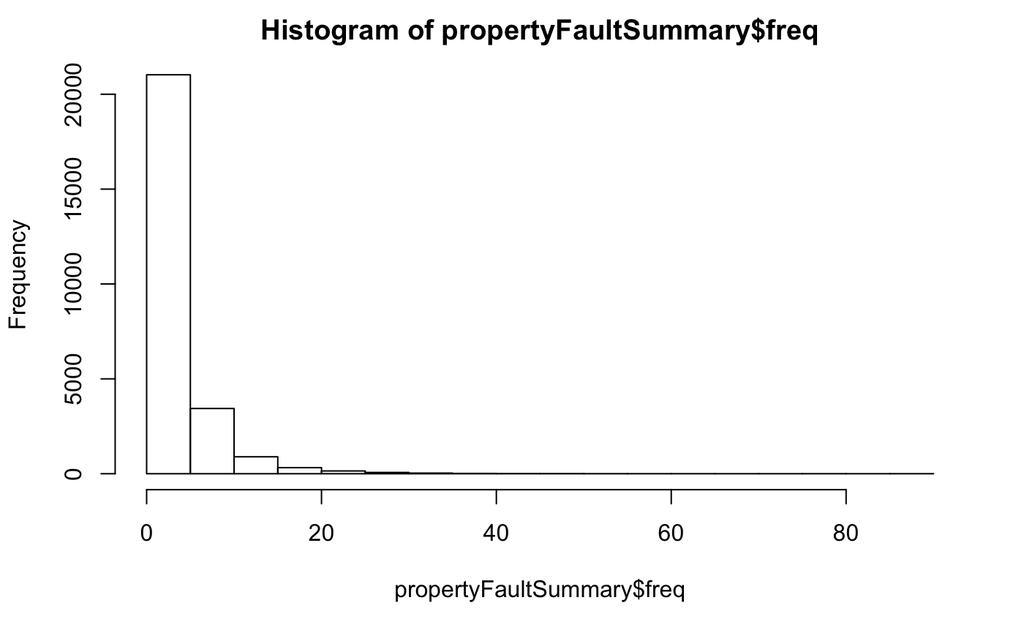

```r
hist(propertyFaultSummary$freq)
```

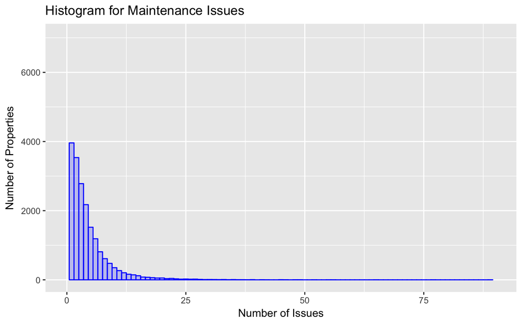

```r
qplot(propertyFaultSummary$freq,
      geom="histogram",
      binwidth = 1,
      main = "Histogram for Maintenance Issues",
      xlab = "Number of Issues",
      ylab = "Number of Properties",
      fill=I("blue"),
      col=I("blue"),
      alpha=I(.2),
      xlim=c(0,90))
```

```r
#We have a heavily right skewed distribution so we'll need to balance it before we can predict.
#See: https://stats.stackexchange.com/questions/107610/what-is-the-reason-the-log-transformation-is-used-with-right-skewed-distribution
```

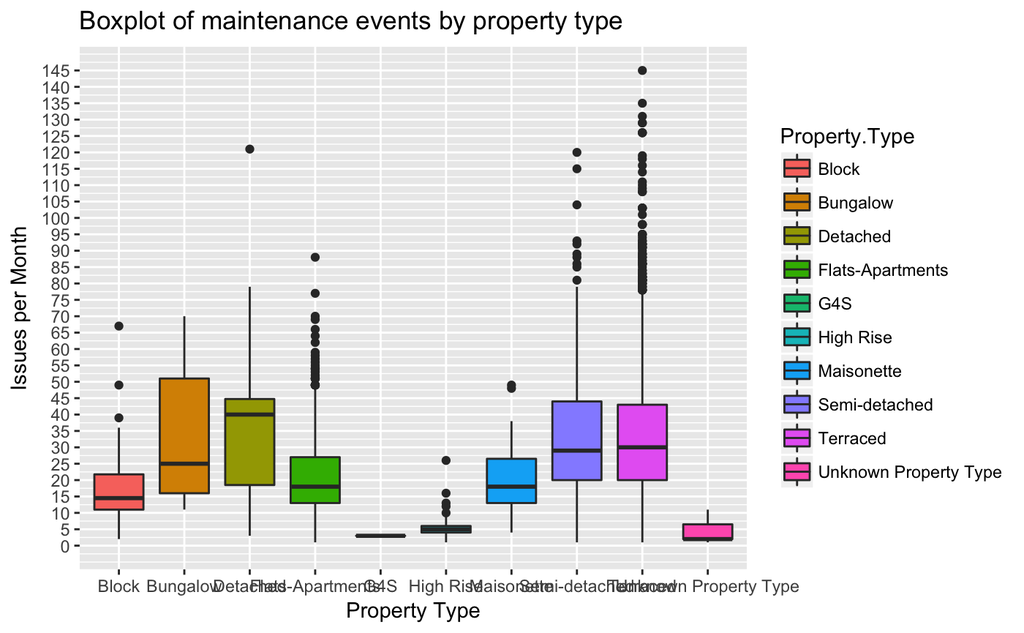

```r
y = count(completeRows, c('ASYS', 'Property.Type'))
#Number of errors by property type
propertyTypeBP1 <- ggplot(y, aes(x = Property.Type, y = freq, fill=Property.Type)) +
        scale_x_discrete(name = "Property Type") +
        scale_y_continuous(name = "Issues per Month", breaks = seq(0, 145, 5), limits=c(0, 145)) +
        ggtitle("Boxplot of maintenance events by property type") +
        geom_boxplot()
propertyTypeBP1
```

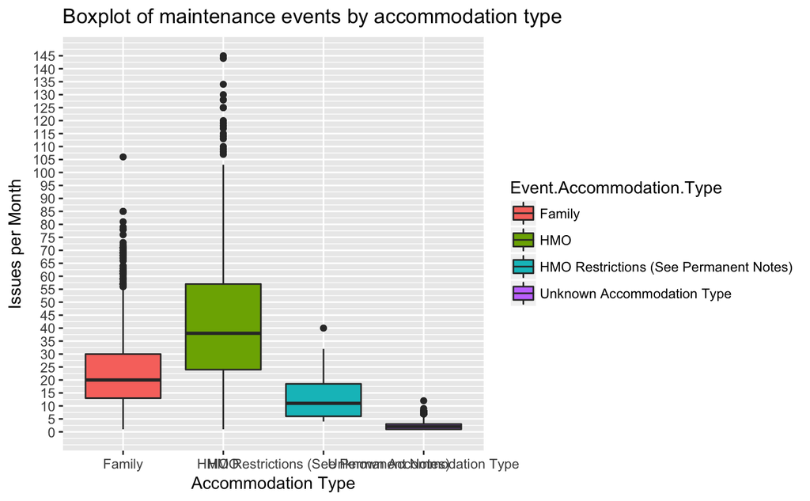

```r
y = count(completeRows, c('ASYS', 'Event.Accommodation.Type'))
#Number of errors by property type
accomTypeBP1 <- ggplot(y, aes(x = Event.Accommodation.Type, y = freq, fill=Event.Accommodation.Type)) +
        scale_x_discrete(name = "Accommodation Type") +
        scale_y_continuous(name = "Issues per Month", breaks = seq(0, 145, 5), limits=c(0, 145)) +
        ggtitle("Boxplot of maintenance events by accommodation type") +
        geom_boxplot()
accomTypeBP1
```

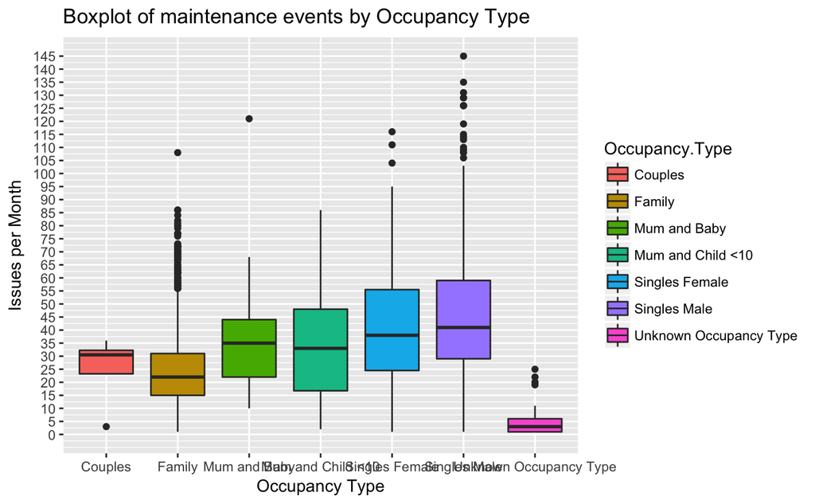

```r
y = count(completeRows, c('ASYS', 'Occupancy.Type'))
#Number of errors by property type
OccupancyTypeBP1 <- ggplot(y, aes(x = Occupancy.Type, y = freq, fill=Occupancy.Type)) +
        scale_x_discrete(name = "Occupancy Type") +
        scale_y_continuous(name = "Issues per Month", breaks = seq(0, 145, 5), limits=c(0, 145)) +
        ggtitle("Boxplot of maintenance events by Occupancy Type") +
        geom_boxplot()
OccupancyTypeBP1
```

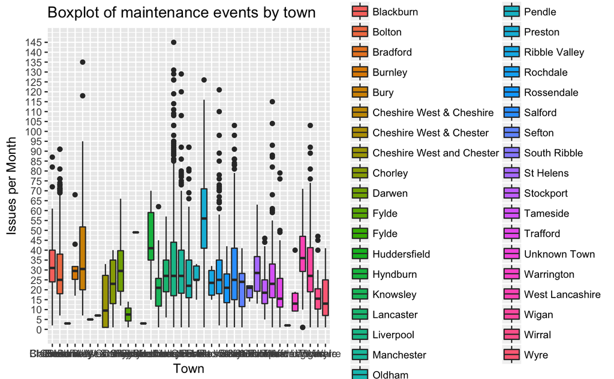

```r
y = count(completeRows, c('ASYS', 'Town'))
#Number of errors by property type
TownBP1 <- ggplot(y, aes(x = Town, y = freq, fill=Town)) +
        scale_x_discrete(name = "Town") +
        scale_y_continuous(name = "Issues per Month", breaks = seq(0, 145, 5), limits=c(0, 145)) +
        ggtitle("Boxplot of maintenance events by town") +
        geom_boxplot()
TownBP1
```

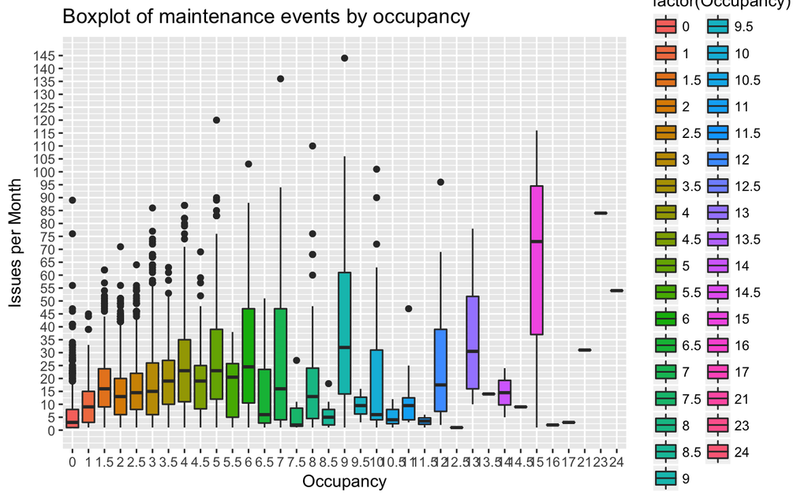

```r
y = count(completeRows, c('ASYS', 'Occupancy'))
#Number of errors by occupancy
OccupancyBP1 <- ggplot(y, aes(x = factor(Occupancy), y = freq, fill=factor(Occupancy))) +
        scale_x_discrete(name = "Occupancy") +
        scale_y_continuous(name = "Issues per Month", breaks = seq(0, 145, 5), limits=c(0, 145)) +
        ggtitle("Boxplot of maintenance events by occupancy") +
        geom_boxplot()
OccupancyBP1
```

*Create ML Data Set - Filter out attributes that wont add anything to our model*

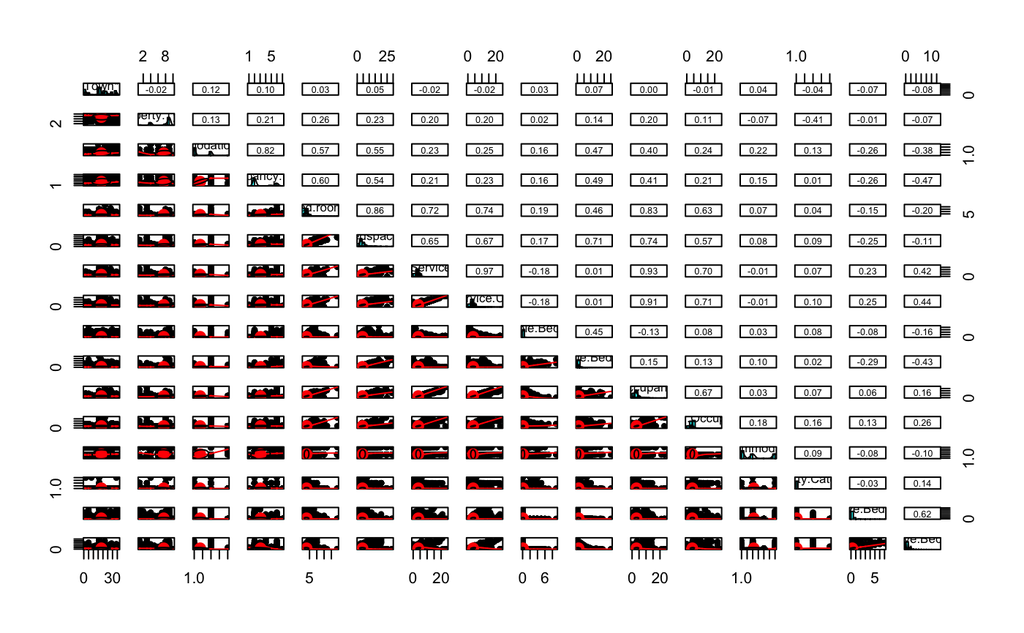

```r
mlSet <- propertyFaultSummary
selectedFeaturesData <- subset(propertyFaultSummary, select = c(Town, Property.Type, Accommodation.Type, Occupancy.Type, Bed.rooms,
                                                                Bedspaces, Active.Service.Users, Active.Service.Users.Plus, Available.Bedrooms, Available.Bedspaces, Occupancy, No.of.Occupants, Event.Accommodation.Type, Property.Category, Negative.Bedspaces, Negative.Bedrooms))
#remove the property identifier and the month - we dont need them and they may colour learning
#mlSet <- mlSet[ , names(mlSet) != "ASYS"]
#mlSet <- mlSet[ , names(mlSet) != "Fault.Identified.Month.Number"]
#mlSet <- mlSet[ , names(mlSet) != "Fault.Reference"]
pairs.panels(selectedFeaturesData, col="red")
```

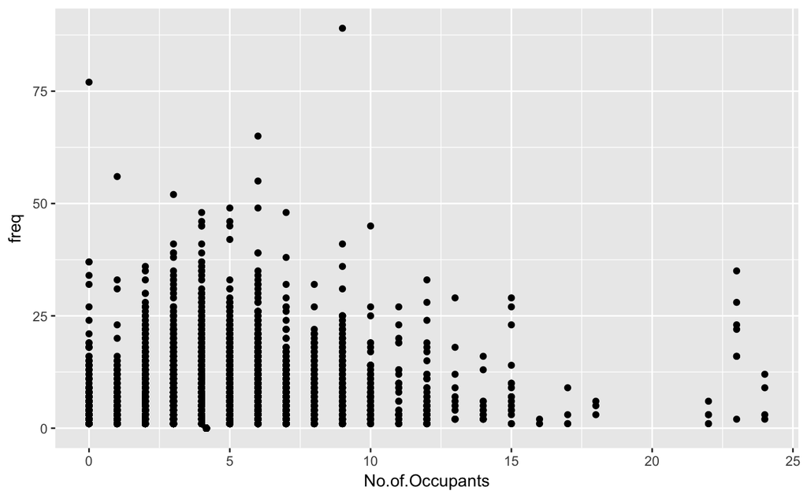

```r
#mlSet
ggplot(mlSet, aes(x=No.of.Occupants, y=freq)) + geom_point()
```

## Starting Machine Learning

We want to use linear regression and predict the number of issues based on location, occupancy, occupant type and property type with 85% accuracy.

```r
#basic stats
summary(mlSet)

#complete roles - no output here means all the rows have values in every column
mlSet <- mlSet[complete.cases(mlSet),]
mlSet[!complete.cases(mlSet),]
```

# *TRIM THE DATASET - REMOVE IF YOU DONT WANT THIS!*

```r
#mlSet = filter(mlSet, freq < 25)
```

*DESKEW

```r
#library(e1071)
#column_classes = sapply(names(mlSet), function(x){class(mlSet[[x]])})
#numeric_columns = names(column_classes[column_classes == "integer" | column_classes == "numeric"])
#skew = sapply(numeric_columns, function(x){skewness(mlSet[[x]], na.rm = T)})
#skew = skew[skew > 0.75]

#Take the natural log of skewed variables
#mlSet_log = mlSet
#for(x in names(skew))
#{
#  if(x != "freq")
#  {
#    mlSet_log[[x]] = log(mlSet_log[[x]] + 1)
#  }
#}
#summary(mlSet_log)
#numeric_columns
```

*Convert our ML Set to a Sparse Matrix so all categorical values are One Hot Encoded*

```r
#to one hot encode all attributes that need it we use the 'sparse.model.matrix' function.  The params are as follows:
#First parameter is the name of the column we are using as output, so it should be ignored.
#Second parameter of '-1' removes an extra column which this command creates as the first column.
#Third parameter specifies the name of the dataset that should be one hot encoded

mlSet_matrix <- sparse.model.matrix(~ .-1, data = mlSet)
#mlSet_matrix <- sparse.model.matrix(~ .-1, data = mlSet_log)
```

*Create Test and Train set*

```r
#force the random number seed so this is repeatable - would remove this in production
set.seed(3456)

#shuffle the dataset
n <- nrow(mlSet_matrix)
shuffled_mlSet_matrix <- mlSet_matrix[sample(n), ]

#split it into train and test set (70/30) using a function
train_indices <- 1:round(0.7 * n)
train_trans <- shuffled_mlSet_matrix[train_indices, ]
test_indices <- (round(0.7 * n) + 1):n
test_trans <- shuffled_mlSet_matrix[test_indices, ]

dim(train_trans)
dim(test_trans)
```

# *Extreme Gradient Boosting*

Not sure this is needed as we’ve done it earlier

```r
#####  Remove columns with NA, use test data as referal for NA
cols.without.na = colSums(is.na(train_trans)) == 0
train_trans = train_trans[, cols.without.na]

cols.without.na = colSums(is.na(test_trans)) == 0
test_trans = test_trans[, cols.without.na]
```

*Check for features’s variance*

Based on the principal component analysis PCA, it is important that features have maximum variance for maximum uniqueness, so that each feature is as distant as possible (as orthogonal as possible) from the other features. This helps us get rid of attributes that don’t add much to the models accuracy but all take time to process.

```r
# check for zero variance - switch 'saveMetrics' to TRUE if you want to take a look at the output, otherwise the output will just be the indicies of the columns that have nearZeroVariance.
zero.var = nearZeroVar(train_trans, saveMetrics=FALSE)
zero.var

#remove any columns where the data in the has near zero variance.  They wont add any value to the model.
train_trans<-train_trans[,-zero.var]
test_trans<-test_trans[, -zero.var]
```

*Explore Data*

```r
explore_train_df <- as.data.frame(as.matrix(train_trans))

explore_train_df  %>%
ggplot(aes(freq)) + geom_histogram(aes(fill = ..count..),bins=40)
ggtitle('Distribution of Response Variable Y')
```

# *Build machine learning model*

Now build a machine learning model to predict faults (freq) from the data (the features or predictors) by using XGBoost extreme gradient boosting algorithm.

*Format data for XGBoost* XGBoost supports only numeric matrix data. Converting all training, testing and outcome data to matrix.

```r
# remove the outcome column (we dont want to give the model the answers and then convert the data to matrix.
train_transtemp <- train_trans
train_transtemp[,'freq'] <- c(NA)

#dont think we need this step as the data is already a matrix
train_trans.matrix = train_transtemp
#train_trans.matrix = as.matrix(train_transtemp)
#mode(train_trans.matrix) = "numeric"

test_trans.matrix = test_trans
#test_trans.matrix = as.matrix(test_trans)
#mode(test_trans.matrix) = "numeric"

#convert the target outcome value into a matrix so xgb can use it
y = as.matrix(as.integer(unlist(train_trans[,"freq"])))
```

```r
#Set seed for reproducability
set.seed(1234)

#See here for more details on the parameters
#https://github.com/dmlc/xgboost/blob/master/doc/parameter.md

# xgboost parameters
xbg_params <- list("objective" = "reg:linear",    # default - linear regression
              "eval_metric" = "rmse",    # evaluation metric
              #"nthread" = 8,   # number of threads to be used - default is max available
              "max_depth" = 6,    # max depth of tree.  Default 6 Increase value will make the model complex / likely overfitting
              "alpha" = 0.6,
              "lambda" = 1.4,
              "eta" = 0.007,    # step size shrinkage - 0.3 default
              "gamma" = 0,    # minimum loss reduction - 0 default
              "subsample" = 1,    # part of data instances to grow tree - 1 default
              "colsample_bytree" = 1  # subsample ratio of columns when constructing each tree - 1 default 1
          )

#nrounds = 30, lambda = 1.4, alpha = 0.6, eta = 0.007


#User Cross Validation checking to spot when our model starts to overfit.  The train RMSE will keep dropping but the test wont.
#Thats how we spot overfitting.
nround.cv = 300
system.time( bst.cv <- xgb.cv(param=xbg_params, data=train_trans.matrix, label=y,
              nfold=7, nrounds=nround.cv, prediction=TRUE, verbose=FALSE) )
```

```r
bst.cv$evaluation_log %>%
  select(-contains("std")) %>%
  gather(TestOrTrain, rmse,-iter) %>%
  ggplot(aes(x = iter, y = rmse, group = TestOrTrain, color = TestOrTrain)) +
  geom_line() +
  theme_bw()

#Get the details of our best iteration
col.names<-colnames(bst.cv$evaluation_log)
setnames(bst.cv$evaluation_log, old = col.names, new = c("iter","train.rmse.mean","train.rmse.std","test.rmse.mean","test.rmse.std" ))

#Get index of minimum rmse
min.rmse.idx = which.min(bst.cv$evaluation_log[, test.rmse.mean])
min.rmse.idx

#Get details of mimimum rmse iteration
bst.cv$dt=bst.cv$evaluation_log
bst.cv$dt[min.rmse.idx,]
```

*Actually Train our model* *Model training* Fit the XGBoost gradient boosting model on all of the training data.

```r
# real model fit training, with full data
system.time( xgb_model <- xgboost(param=xbg_params, data=train_trans.matrix, label=y,
                           nrounds=min.rmse.idx, verbose=0) )
```

*Make predictions for the testing data*

```r
# xgboost predict test data using the trained model
pred <- predict(xgb_model, test_trans.matrix)
head(pred, 10)
```

*Look at Feature importance* - which attributes does our model think are important

```r
# get the trained model
model = xgb.dump(xgb_model, with_stats=TRUE)
# get the feature real names
names = dimnames(train_trans.matrix)[[2]]
# compute feature importance matrix
importance_matrix = xgb.importance(names, model=xgb_model)

# plot
gp = xgb.plot.importance(importance_matrix)
print(gp)
```

*Join the predictions to the original data set and see how well we did*

```r
#turn our predictions back into a data frame
df <- data.frame(matrix(unlist(pred), nrow=nrow(test_trans), byrow=T),stringsAsFactors=FALSE)
test_trans_df <- as.data.frame(as.matrix(test_trans))
```

```r
#make a dataframe that contains all the original training data and the predicted score
xbgNewResults <- data.frame(test_trans_df, prediction = df[1])
#xbgNewResults <- data.frame(test_trans_df, prediction = exp(df[1]))
colnames(xbgNewResults)[ncol(xbgNewResults)] <- "prediction"
xbgNewResults$RoundedPrediction <- round(xbgNewResults$prediction,digits=0)
xbgNewResults
```

```r
rmse(xbgNewResults$freq, xbgNewResults$prediction)
rmse(xbgNewResults$freq, xbgNewResults$RoundedPrediction)
cat("Percentage Wrong ", length(which(xbgNewResults$freq != xbgNewResults$RoundedPrediction)) / nrow(xbgNewResults)*100, "%")

cat("Actual Faults ", sum(xbgNewResults$freq))
cat("Predicted Faults ", sum(xbgNewResults$RoundedPrediction))
```

# XGB from Caret

```r
myControl = trainControl(method = "cv", number = 5, verboseIter = TRUE)

model_xgb4 = train(freq ~ .,
                   data = as.data.frame(as.matrix(train_trans)),
                   tuneLength = 2,
                   method = "xgbLinear",
                   control = "myControl"
                   )
```

```r
#5 fold cross validation
myControl = trainControl(method = "cv", number = 5)

#xbg_params <- list("objective" = "reg:linear",    # default - linear regression
#              "eval_metric" = "rmse",    # evaluation metric
#              #"nthread" = 8,   # number of threads to be used - default is max available
#              "max_depth" = 6,    # max depth of tree. Default 6 Increase value will make the model complex / #likely overfitting
#              "eta" = 0.01,    # step size shrinkage - 0.3 default
#              "gamma" = 0,    # minimum loss reduction - 0 default
#              "subsample" = 1,    # part of data instances to grow tree - 1 default
#              "colsample_bytree" = 1  # subsample ratio of columns when constructing each tree - 1 default 1
#          )

#generate a set of all combinations - this was our original
#'c' is a list of absolute values
#'seq' generates a sequence of numbers between the first parameter and the second, using sets of the third.
#xgbTuningGrid = expand.grid(nrounds = c(50, 100, 1000, 1500),
#                            lambda = seq(0.1, 1.0, 0.1),
#                            alpha = seq(0.1, 1.5, 0.1),
#                            eta = c(0.01, 0.05, 0.1, 0.2, 0.3, 0.4, 0.5))

#This was our second attempt
#xgbTuningGrid = expand.grid(nrounds = c(50, 60, 70, 100, 1000),
#                            lambda = seq(0.2, 1.0, 0.2),
#                            alpha = seq(0, 1.6, 0.2),
#                            eta = c(0.01, 0.02, 0.1, 0.3))

#xgbTuningGrid = expand.grid(nrounds = c(30,40, 50),
#                            lambda = seq(1.0, 1.5, 0.1),
#                            alpha = seq(0.4, 1.6, 0.2),
#                            eta = c(0.007, 0.008, 0.009, 0.01))

#xgbTuningGrid = expand.grid(nrounds = c(50,200,300),
#                            lambda = seq(0.1, 1.0, 0.1),
#                            alpha = seq(0.1, 1.5, 0.5),
#                            eta = c(0.001, 0.01, 0.03))

xgbTuningGrid = expand.grid(nrounds = c(50, 100),
                            lambda = seq(0.1, 0.5, 0.1),
                            alpha = seq(0.1, 0.5, 0.1),
                            eta = c(0.3, 0.4))


xgbTuningGrid
```

```r
# xgboost parameters
#xbg_params <- list("objective" = "reg:linear",    # default - linear regression
#              "eval_metric" = "rmse",    # evaluation metric
#              #"nthread" = 8,   # number of threads to be used - default is max available
#              "max_depth" = 6,    # max depth of tree.  Default 6 Increase value will make the model #complex / likely overfitting
#              "eta" = 0.3,    # step size shrinkage - 0.3 default
#              "gamma" = 0,    # minimum loss reduction - 0 default
#              "subsample" = 1,    # part of data instances to grow tree - 1 default
#              "colsample_bytree" = 1  # subsample ratio of columns when constructing each tree - 1 #default 1
#          )

xbg_params <- list("objective" = "reg:linear",    # default - linear regression
              "eval_metric" = "rmse",    # evaluation metric
              #"nthread" = 8,   # number of threads to be used - default is max available
              "max_depth" = 6,    # max depth of tree.  Default 6 Increase value will make the model complex / likely overfitting
              "eta" = 0.01,    # step size shrinkage - 0.3 default
              "gamma" = 0,    # minimum loss reduction - 0 default
              "subsample" = 1,    # part of data instances to grow tree - 1 default
              "colsample_bytree" = 1  # subsample ratio of columns when constructing each tree - 1 default 1
          )

myControl = trainControl(method = "cv", number = 5, verboseIter = FALSE)

model_xgb4g = train(freq ~ .,
                   data = as.data.frame(as.matrix(train_trans)),
                   tuneLength = 3,
                   method = "xgbLinear",
                   trControl = myControl,
                   tuneGrid = xgbTuningGrid,
                   verbose = FALSE)
```

```r
trellis.par.set(caretTheme())
plot(model_xgb4g)

model_xgb4g$results
#this is easier to read
ggplot(model_xgb4g)
#filter by lambda=.08 or lambda=1
```

```r
# get the top model and its results
head(model_xgb4g$results[with(model_xgb4g$results,
                             order(RMSE)), ], 1)

yhatXgb <- predict(model_xgb4g, newdata = as.data.frame(as.matrix(test_trans)))
mean((yhatXgb - as.data.frame(as.matrix(test_trans))$freq) ^ 2) # 15.49

plot(as.data.frame(as.matrix(test_trans))$freq, yhatXgb, col = "red")
abline(0, 1, col = "blue")

# Variable Importance
names <- names(as.data.frame(as.matrix(train_trans)))[! names(as.data.frame(as.matrix(train_trans))) %in% c("freq")]
importanceMatrix <- xgb.importance(names,
                                   model = model_xgb4g$finalModel)
xgb.plot.importance(importanceMatrix[1:10,])
```

```r
#GET THE NICE GRAPH
#User Cross Validation checking to spot when our model starts to overfit.  The train RMSE will keep dropping but the test wont.
#Thats how we spot overfitting.
nround.cv = 300
system.time( bst.cv <- xgb.cv(param=xbg_params, data=train_trans.matrix, label=y,
              nfold=4, nrounds=nround.cv, prediction=TRUE, verbose=FALSE) )

bst.cv$evaluation_log %>%
  select(-contains("std")) %>%
  gather(TestOrTrain, rmse,-iter) %>%
  ggplot(aes(x = iter, y = rmse, group = TestOrTrain, color = TestOrTrain)) +
  geom_line() +
  theme_bw()

#Get the details of our best iteration
col.names<-colnames(bst.cv$evaluation_log)
setnames(bst.cv$evaluation_log, old = col.names, new = c("iter","train.rmse.mean","train.rmse.std","test.rmse.mean","test.rmse.std" ))

#Get index of minimum rmse
min.rmse.idx = which.min(bst.cv$evaluation_log[, test.rmse.mean])
min.rmse.idx

#Get details of mimimum rmse iteration
bst.cv$dt=bst.cv$evaluation_log
bst.cv$dt[min.rmse.idx,]
```

*Actually Train our model* *Model training* Fit the XGBoost gradient boosting model on all of the training data.

```r
# real model fit training, with full data
system.time( xgb_model <- xgboost(param=xbg_params, data=train_trans.matrix, label=y,
                           nrounds=min.rmse.idx, verbose=0) )
```

*Make predictions for the testing data*

```r
# xgboost predict test data using the trained model
pred <- predict(xgb_model, test_trans.matrix)
head(pred, 10)
```

*Look at Feature importance* - which attributes does our model think are important

```r
# get the trained model
model = xgb.dump(xgb_model, with_stats=TRUE)
# get the feature real names
names = dimnames(train_trans.matrix)[[2]]
# compute feature importance matrix
importance_matrix = xgb.importance(names, model=xgb_model)

# plot
gp = xgb.plot.importance(importance_matrix)
print(gp)
```

*Join the predictions to the original data set and see how well we did*

```r
#turn our predictions back into a data frame
df <- data.frame(matrix(unlist(pred), nrow=nrow(test_trans), byrow=T),stringsAsFactors=FALSE)
test_trans_df <- as.data.frame(as.matrix(test_trans))
```

```r
#make a dataframe that contains all the original training data and the predicted score
#xbgNewResults <- data.frame(y, freq = df[1])
xbgNewResults <- data.frame(test_trans_df, prediction = df[1])
colnames(xbgNewResults)[ncol(xbgNewResults)] <- "prediction"
xbgNewResults$RoundedPrediction <- round(xbgNewResults$prediction,digits=0)
xbgNewResults
```

```r
rmse(xbgNewResults$freq, xbgNewResults$prediction)
rmse(xbgNewResults$freq, xbgNewResults$RoundedPrediction)
cat("Percentage Wrong ", length(which(xbgNewResults$freq != xbgNewResults$RoundedPrediction)) / nrow(xbgNewResults)*100, "%")

cat("Actual Faults ", sum(xbgNewResults$freq))
cat("Predicted Faults ", sum(xbgNewResults$RoundedPrediction))
```